# 数学建模

### 模型知识点

### 优化模型-图论模型-基本理论

**Wang Haihua**

🚅 🚋😜 🚑 🚔

图论中所说的图，不是图形图像或地图，而是指由顶点和边所构成的图形结构。 图论不仅与拓扑学、计算机数据结构和算法密切相关，而且正在成为机器学习的关键技术。 本系列结合数学建模的应用需求，来介绍 NetworkX 图论与复杂网络工具包的基本功能和典型算法。

## 1. 图论

### 1.1 图论是什么

图论〔Graph Theory〕以图为研究对象，是离散数学的重要内容。图论不仅与拓扑学、计算机数据结构和算法密切相关，而且正在成为机器学习的关键技术。

图论中所说的图，不是指图形图像（image）或地图（map），而是指由顶点（vertex）和连接顶点的边（edge）所构成的关系结构。

图提供了一种处理关系和交互等抽象概念的更好的方法，它还提供了直观的视觉方式来思考这些概念。

### 1.2 NetworkX 工具包

NetworkX 是基于 Python 语言的图论与复杂网络工具包，用于创建、操作和研究复杂网络的结构、动力学和功能。

NetworkX 可以以标准和非标准的数据格式描述图与网络，生成图与网络，分析网络结构，构建网络模型，设计网络算法，绘制网络图形。

NetworkX 提供了图形的类、对象、图形生成器、网络生成器、绘图工具，内置了常用的图论和网络分析算法，可以进行图和网络的建模、分析和仿真。

NetworkX 的功能非常强大和庞杂，所涉及内容远远、远远地超出了数学建模的范围，甚至于很难进行系统的概括。本系列结合数学建模的应用需求，来介绍 NetworkX 图论与复杂网络工具包的基本功能和典型算法。

NetworkX 的官网和文档

官网地址：https://networkx.org/ 官方文档：https://networkx.org/documentation/stable/ pdf 文档：https://networkx.org/documentation/stable/_downloads/networkx_reference.pdf

## 2、图、顶点和边的创建与基本操作

**图由顶点和连接顶点的边构成，但与顶点的位置、边的曲直长短无关。**

Networkx 支持创建简单无向图、有向图和多重图；内置许多标准的图论算法，节点可为任意数据；支持任意的边值维度，功能丰富，简单易用。

### 2.1 图的基本概念

- 图（Graph）：图是由若干顶点和连接顶点的边所构成关系结构。
- 顶点（Node）：图中的点称为顶点，也称节点。
- 边（Edge）：顶点之间的连线，称为边。
- 平行边（Parallel edge）：起点相同、终点也相同的两条边称为平行边。
- 循环（Cycle）：起点和终点重合的边称为循环。
- 有向图（Digraph）：图中的每条边都带有方向，称为有向图。
- 无向图（Undirected graph）：图中的每条边都没有方向，称为无向图。
- 赋权图（Weighted graph）：图中的每条边都有一个或多个对应的参数，称为赋权图。该参数称为这条边的权，权可以用来表示两点间的距离、时间、费用。
- 度（Degree）：与顶点相连的边的数量，称为该顶点的度。

### 2.2 图、顶点和边的操作

Networkx很容易创建图、向图中添加顶点和边、从图中删除顶点和边，也可以查看、删除顶点和边的属性。

#### 2.2.1 图的创建

Graph() 类、DiGraph() 类、MultiGraph() 类和 MultiDiGraph() 类分别用来创建：无向图、有向图、多图和有向多图。定义和例程如下：

class Graph(incoming_graph_data=None, **attr)

```python
import networkx as nx  # 导入 NetworkX 工具包

# 创建 图
G1 = nx.Graph()  # 创建：空的 无向图
G2 = nx.DiGraph()  #创建：空的 有向图
G3 = nx.MultiGraph()  #创建：空的 多图
G4 = nx.MultiDiGraph()  #创建：空的 有向多图
```

#### 2.2.2 顶点的添加、删除和查看

图的每个顶点都有唯一的标签属性（label），可以用整数或字符类型表示，顶点还可以自定义任意属性。

顶点的常用操作：添加顶点，删除顶点，定义顶点属性，查看顶点和顶点属性。定义和例程如下：

`Graph.add_node(node_for_adding, **attr)`  
`Graph.add_nodes_from(nodes_for_adding, **attr)`  
`Graph.remove_node(n)`  
`Graph.remove_nodes_from(nodes)`

```python
# 顶点(node)的操作
# 向图中添加顶点
G1.add_node(1)  # 向 G1 添加顶点 1
G1.add_node(1, name='n1', weight=1.0)  # 添加顶点 1，定义 name, weight 属性
G1.add_node(2, date='May-16') # 添加顶点 2，定义 time 属性
G1.add_nodes_from([3, 0, 6], dist=1)  # 添加多个顶点，并定义属性
G1.add_nodes_from(range(10, 15))  # 向图 G1 添加顶点 10～14

# 查看顶点和顶点属性
print(G1.nodes())  # 查看顶点列表
# [1, 2, 3, 0, 6, 10, 11, 12, 13, 14]
print(G1._node)  # 查看顶点属性
# {1: {'name': 'n1', 'weight': 1.0}, 2: {'date': 'May-16'}, 3: {'dist': 1}, 0: {'dist': 1}, 6: {'dist': 1}, 10: {}, 11: {}, 12: {}, 13: {}, 14: {}}

# 从图中删除顶点
G1.remove_node(1)  # 删除顶点
G1.remove_nodes_from([1, 11, 13, 14])  # 通过顶点标签的 list 删除多个顶点
print(G1.nodes())  # 查看顶点
# [2, 3, 0, 6, 10, 12]  # 顶点列表
```

```
[1, 2, 3, 0, 6, 10, 11, 12, 13, 14]
{1: {'name': 'n1', 'weight': 1.0}, 2: {'date': 'May-16'}, 3: {'dist': 1}, 0: {'dist': 1}, 6: {'dist': 1}, 10: {}, 11: {}, 12: {}, 13: {}, 14: {}}
[2, 3, 0, 6, 10, 12]
```

#### 2.2.3 边的添加、删除和查看

边是两个顶点之间的连接，在 NetworkX 中 边是由对应顶点的名字的元组组成 e=(node1,node2)。边可以设置权重、关系等属性。

边的常用操作：添加边，删除边，定义边的属性，查看边和边的属性。向图中添加边时，如果边的顶点是图中不存在的，则自动向图中添加该顶点。

`Graph.add_edge(u_of_edge, v_of_edge, **attr)`  
`Graph.add_edges_from(ebunch_to_add, **attr)`  
`Graph.add_weighted_edges_from(ebunch_to_add, weight='weight', **attr)`

```python
# 边(edge)的操作
# 向图中添加边
G1.add_edge(1,5)  # 向 G1 添加边，并自动添加图中没有的顶点
G1.add_edge(0,10, weight=2.7)  # 向 G1 添加边，并设置边的属性
G1.add_edges_from([(1,2,{'weight':0}), (2,3,{'color':'blue'})])  # 向图中添加边，并设置属性
G1.add_edges_from([(3,6),(1,2),(6,7),(5,10),(0,1)])  # 向图中添加多条边
G1.add_weighted_edges_from([(1,2,3.6),[6,12,0.5]])  # 向图中添加多条赋权边: (node1,node2,weight)
print(G1.nodes())  # 查看顶点
# [2, 3, 0, 6, 10, 12, 1, 5, 7]  # 自动添加了图中没有的顶点

# 从图中删除边
G1.remove_edge(0,1)  # 从图中删除边 0-1
G1.remove_edges_from([(2,3),(1,5),(6,7)])  # 从图中删除多条边


# 查看 边和边的属性
print(G1.edges)  # 查看所有的边
[(2, 1), (3, 6), (0, 10), (6, 12), (10, 5)]
print(G1.get_edge_data(1,2))  # 查看指定边的属性
# {'weight': 3.6}
print(G1[1][2])  # 查看指定边的属性
# {'weight': 3.6}
print(G1.edges(data=True))  # 查看所有边的属性
# [(2, 1, {'weight': 3.6}), (3, 6, {}), (0, 10, {'weight': 2.7}), (6, 12, {'weight': 0.5}), (10, 5, {})]
```

```
[2, 3, 0, 6, 10, 12, 1, 5, 7]
[(2, 1), (3, 6), (0, 10), (6, 12), (10, 5)]
{'weight': 3.6}
{'weight': 3.6}
[(2, 1, {'weight': 3.6}), (3, 6, {}), (0, 10, {'weight': 2.7}), (6, 12, {'weight': 0.5}), (10, 5, {})]
```

#### 2.2.4 查看图、顶点和边的信息

```python
# 查看图、顶点和边的信息
print(G1.nodes)  # 返回所有的顶点 [node1,...]
# [2, 3, 0, 6, 10, 12, 1, 5, 7]
print(G1.edges)  # 返回所有的边 [(node1,node2),...]
# [(2, 1), (3, 6), (0, 10), (6, 12), (10, 5)]
print(G1.degree)  # 返回各顶点的度 [(node1,degree1),...]
# [(2, 1), (3, 1), (0, 1), (6, 2), (10, 2), (12, 1), (1, 1), (5, 1), (7, 0)]
print(G1.number_of_nodes())  # 返回顶点的数量
# 9
print(G1.number_of_edges())  # 返回边的数量
# 5
print(G1[10])  # 返回与指定顶点相邻的所有顶点的属性
# {0: {'weight': 2.7}, 5: {}}
print(G1.adj[10])  # 返回与指定顶点相邻的所有顶点的属性
# {0: {'weight': 2.7}, 5: {}}
print(G1[1][2])  # 返回指定边的属性
# {'weight': 3.6}
print(G1.adj[1][2])  # 返回指定边的属性
# {'weight': 3.6}
print(G1.degree(10))  # 返回指定顶点的度
# 2
```

```python
print('nx.info:',nx.info(G1))  # 返回图的基本信息
print('nx.degree:',nx.degree(G1))  # 返回图中各顶点的度
print('nx.density:',nx.degree_histogram(G1))  # 返回图中度的分布
print('nx.pagerank:',nx.pagerank(G1))  # 返回图中各顶点的频率分布
```

```
[2, 3, 0, 6, 10, 12, 1, 5, 7]
[(2, 1), (3, 6), (0, 10), (6, 12), (10, 5)]
[(2, 1), (3, 1), (0, 1), (6, 2), (10, 2), (12, 1), (1, 1), (5, 1), (7, 0)]
9
5
{0: {'weight': 2.7}, 5: {}}
{0: {'weight': 2.7}, 5: {}}
{'weight': 3.6}
{'weight': 3.6}
2
nx.info: Name:
Type: Graph
Number of nodes: 9
Number of edges: 5
Average degree:   1.1111
nx.degree: [(2, 1), (3, 1), (0, 1), (6, 2), (10, 2), (12, 1), (1, 1), (5, 1), (7, 0)]
nx.density: [1, 6, 2]
nx.pagerank: {2: 0.1226993865030675, 3: 0.11988128948774181, 0: 0.1294804066578225, 6: 0.17907377128985963, 10: 0.17907377128985968, 12: 0.06914309873160096, 1: 0.1226993865030675, 5: 0.059543981561520264, 7: 0.018404907975460127}
```

### 2.3 图的属性和方法

图的方法

```python
import matplotlib.pyplot as plt
G1.clear() # 清空图G1
nx.add_star(G1, [1, 2, 3, 4, 5], weight=1)  # 添加星形网络：以第一个顶点为中心
# [(1, 2), (1, 3), (1, 4), (1, 5)]
nx.add_path(G1, [5, 6, 8, 9, 10], weight=2)  # 添加路径：顺序连接 n个节点的 n-1条边
# [(5, 6), (6, 8), (8, 9), (9, 10)]
nx.add_cycle(G1, [7, 8, 9, 10, 12], weight=3)  # 添加闭合回路：循环连接 n个节点的 n 条边
# [(7, 8), (7, 12), (8, 9), (9, 10), (10, 12)]
print(G1.nodes)  # 返回所有的顶点 [node1,...]
nx.draw_networkx(G1)
plt.show()

G2 = G1.subgraph([1, 2, 3, 8, 9, 10])
G3 = G1.subgraph([4, 5, 6, 7])
```

```
[1, 2, 3, 4, 5, 6, 8, 9, 10, 7, 12]
```

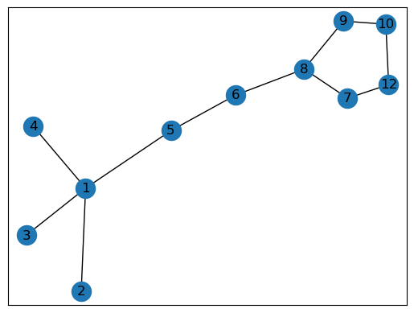

[output not shown]

```python
G = nx.union(G2, G3)
print(G.nodes)  # 返回所有的顶点 [node1,...]
# [1, 2, 3, 8, 9, 10, 4, 5, 6, 7]
```

## 3、图的绘制与分析

### 3.1 图的绘制

可视化是图论和网络问题中很重要的内容。NetworkX 在 Matplotlib、Graphviz 等图形工具包的基础上，提供了丰富的绘图功能。

本系列拟对图和网络的可视化作一个专题，在此只简单介绍基于 Matplotlib 的基本绘图函数。基本绘图函数使用字典提供的位置将节点放置在散点图上，或者使用布局函数计算位置。

其中，nx.draw() 和 nx.draw_networkx() 是最基本的绘图函数，并可以通过自定义函数属性或其它绘图函数设置不同的绘图要求。

`draw(G, pos=None, ax=None, **kwds)`

### 3.2 图的分析

NetwotkX 提供了图论函数对图的结构进行分析：

子图

子图是指顶点和边都分别是图 G 的顶点的子集和边的子集的图。 subgraph()方法，按顶点从图 G 中抽出子图。例程如前。 连通子图

如果图 G 中的任意两点间相互连通，则 G 是连通图。 connected_components()方法，返回连通子图的集合。

```python
G = nx.path_graph(4)
nx.add_path(G, [7, 8, 9])
# 连通子图
listCC = [len(c) for c in sorted(nx.connected_components(G), key=len, reverse=True)]
maxCC = max(nx.connected_components(G), key=len)
print('Connected components:{}'.format(listCC))  # 所有连通子图
# Connected components:[4, 3]
print('Largest connected components:{}'.format(maxCC))  # 最大连通子图
# Largest connected components:{0, 1, 2, 3}
```

```
Connected components:[4, 3]
Largest connected components:{0, 1, 2, 3}
```

强连通

如果有向图 G 中的任意两点间相互连通，则称 G 是强连通图。 strongly_connected_components()方法，返回所有强连通子图的列表。

```python
# 强连通
G = nx.path_graph(4, create_using=nx.DiGraph())
nx.add_path(G, [3, 8, 1])
# 找出所有的强连通子图
con = nx.strongly_connected_components(G)
print(type(con),list(con))
# <class 'generator'> [{8, 1, 2, 3}, {0}]
```

```
<class 'generator'> [{8, 1, 2, 3}, {0}]
```

弱连通

如果一个有向图 G 的基图是连通图，则有向图 G 是弱连通图。 weakly_connected_components()方法，返回所有弱连通子图的列表。

```python
# 弱连通
G = nx.path_graph(4, create_using=nx.DiGraph())  #默认生成节点 0,1,2,3 和有向边 0->1,1->2,2->3
nx.add_path(G, [7, 8, 3])  #生成有向边：7->8->3
con = nx.weakly_connected_components(G)
print(type(con),list(con))
# <class 'generator'> [{0, 1, 2, 3, 7, 8}]
```

```
<class 'generator'> [{0, 1, 2, 3, 7, 8}]
```

**参考文献**

- youcans Python小白的数学建模课 https://www.zhihu.com/column/c_1381900867424075776
- 司守奎、孙兆亮，数学建模算法与应用（第2版）